# HIV - Human Immunodeficiency Virus

Danijel Merlo, 173192

# Perché?

Il progetto è stato intrapreso per analizzare l’andamento dell’HIV a livello globale e comprendere meglio la distribuzione dei casi e dei decessi, al fine di sensibilizzare sul tema.

# Il dominio:

Il dominio è importante perché l’HIV colpisce milioni di persone nel mondo, e l’analisi dei dati epidemiologici permette di identificare aree critiche, valutare interventi sanitari e migliorare la consapevolezza globale sul virus.

# Conoscenze:

Si parte da conoscenze di base su epidemiologia, statistiche descrittive e visualizzazione dati, nonché familiarità con dataset sanitari e strumenti di analisi come Python, Pandas e Seaborn.

# Domande che mi sono posto:

- Quali paesi hanno il maggior numero di persone viventi con HIV e di decessi?
- Come si distribuiscono i casi per regione e anno?
- Cosa cambia nelle differenti fasce d’età?

Analisi dei dati relativi all'HIV, principali focalizzazioni su:

- Persone che vivono con l'HIV
- Numero di decessi
- Casi nella fascia di età 15–49 anni

L'obiettivo è evidenziare le tendenze globali, le differenze regionali e nazionali, e i vari legami.

# Dataset utilizzati:

Fonte: Kaggle  
Link: https://www.kaggle.com/datasets/imdevskp/hiv-aids-dataset/data  
Autore: Devakumar K.P.

1. `no_of_people_living_with_hiv_by_country_clean.csv` (Persone che vivono con HIV)
2. `no_of_deaths_by_country_clean.csv` (Decessi per HIV)
3. `no_of_cases_adults_15_to_49_by_country_clean.csv` (Casi, età 15–49)

## 1) Caricamento e pulizia dei dataset

- Carichiamo e puliamo le colonne numeriche.
- Analisi esplorativa
- Ultimo anno disponibile: 2018

```
Anteprima hiv_living:
```

|  | Country | Year | Count | Count_median | Count_min | Count_max | WHO Region |
| --- | --- | --- | --- | --- | --- | --- | --- |
| 0 | Afghanistan | 2018 | 7200.0 | 7200.0 | 4100.0 | 11000.0 | Eastern Mediterranean |
| 1 | Albania | 2018 | NaN | NaN | NaN | NaN | Europe |
| 2 | Algeria | 2018 | 16000.0 | 16000.0 | 15000.0 | 17000.0 | Africa |
| 3 | Angola | 2018 | 330000.0 | 330000.0 | 290000.0 | 390000.0 | Africa |
| 4 | Argentina | 2018 | 140000.0 | 140000.0 | 130000.0 | 150000.0 | Americas |

```
Anteprima hiv_deaths:
```

|  | Country | Year | Count | Count_median | Count_min | Count_max | WHO Region |
| --- | --- | --- | --- | --- | --- | --- | --- |
| 0 | Afghanistan | 2018 | 500.0 | 500.0 | 200.0 | 610.0 | Eastern Mediterranean |
| 1 | Albania | 2018 | NaN | NaN | NaN | NaN | Europe |
| 2 | Algeria | 2018 | 200.0 | 200.0 | 200.0 | 200.0 | Africa |
| 3 | Angola | 2018 | 14000.0 | 14000.0 | 9500.0 | 18000.0 | Africa |
| 4 | Argentina | 2018 | 1700.0 | 1700.0 | 1300.0 | 2100.0 | Americas |

```
Anteprima hiv_cases:
```

|  | Country | Year | Count | Count_median | Count_min | Count_max | WHO Region |
| --- | --- | --- | --- | --- | --- | --- | --- |
| 0 | Afghanistan | 2018 | 0.1 | 0.1 | 0.1 | 0.1 | Eastern Mediterranean |
| 1 | Albania | 2018 | NaN | NaN | NaN | NaN | Europe |
| 2 | Algeria | 2018 | 0.1 | 0.1 | 0.1 | 0.1 | Africa |
| 3 | Angola | 2018 | 2.0 | 2.0 | 1.7 | 2.3 | Africa |
| 4 | Argentina | 2018 | 0.4 | 0.4 | 0.4 | 0.4 | Americas |

## 3) Andamento globale comparato

Questo grafico mostra le serie temporali globali aggregate per **Persone con HIV** e **Decessi**.

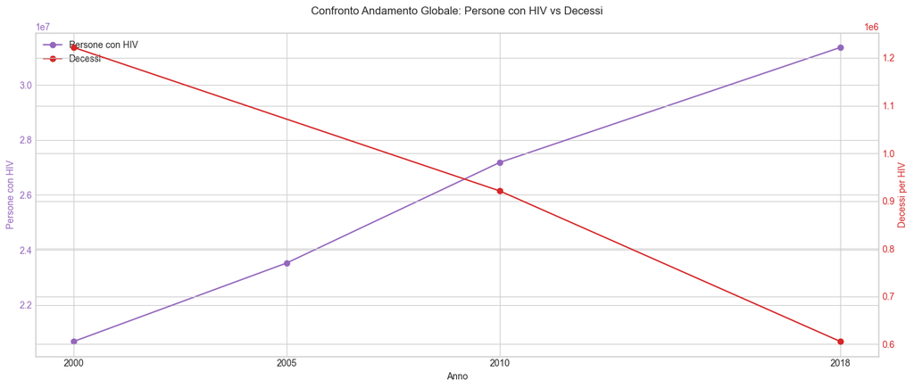

### 3.2 Mappe interattive arricchite (ultimo anno - 2018)

Mappe con evidenziata la distribuzione geografica dell'HIV. Ogni paese è colorato in base ai valori registrati, in modo da visualizzare quali regioni hanno i numeri più alti.

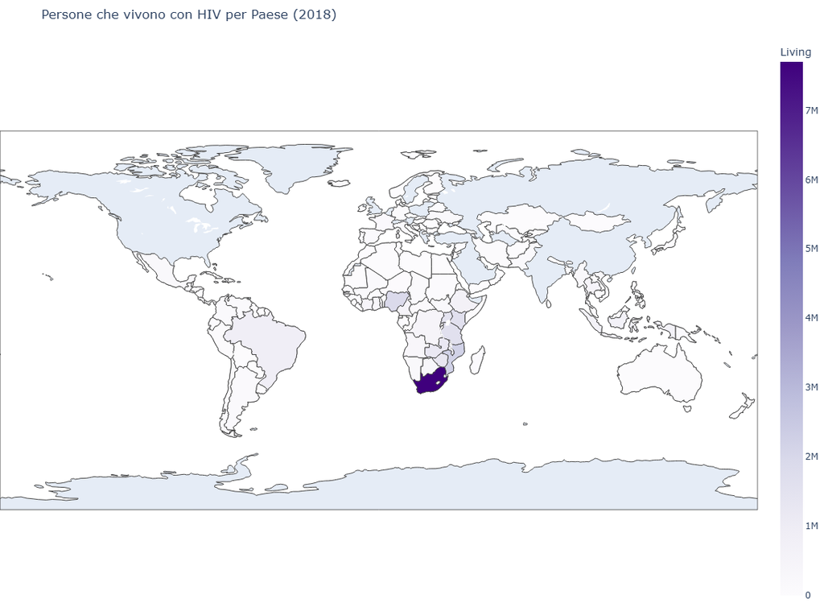

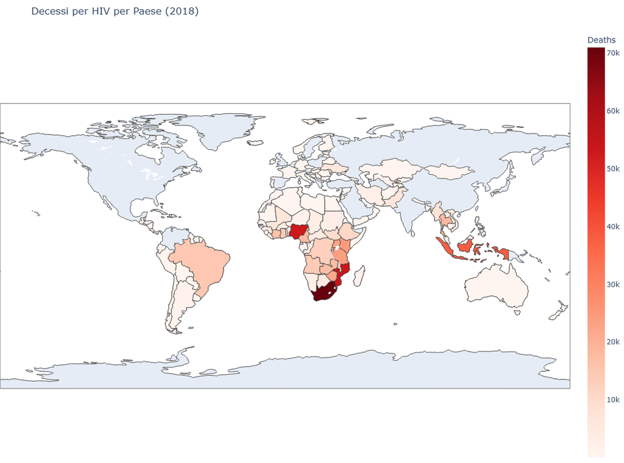

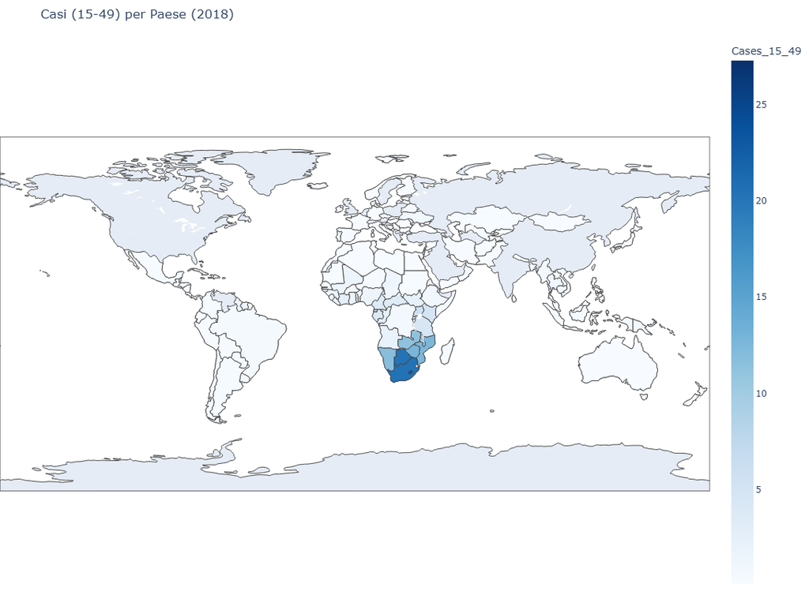

## 4) Top 15 e confronti

Classifica dei 15 paesi con più persone che vivono con l'HIV

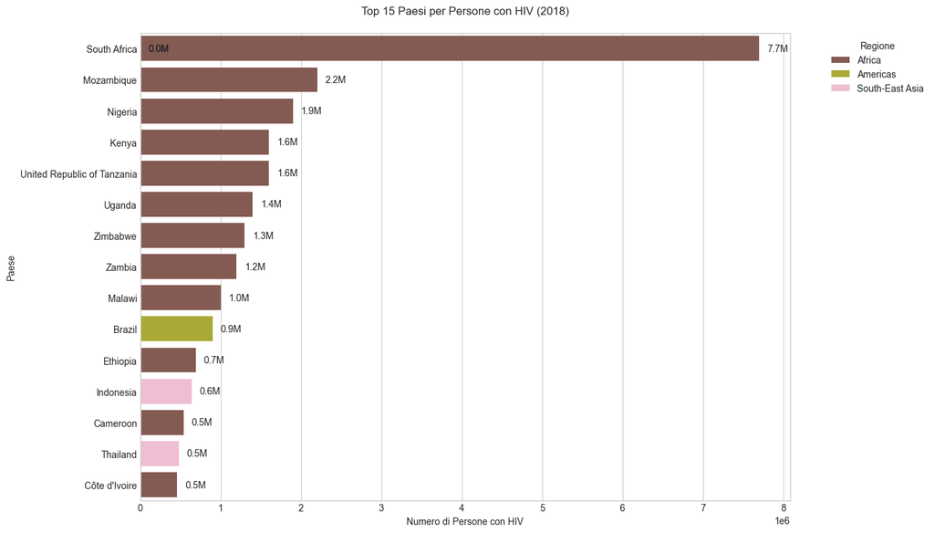

### 4.2 Confronto dei continenti

Confronto dei continenti/regioni geografiche, persone che vivono con l'HIV

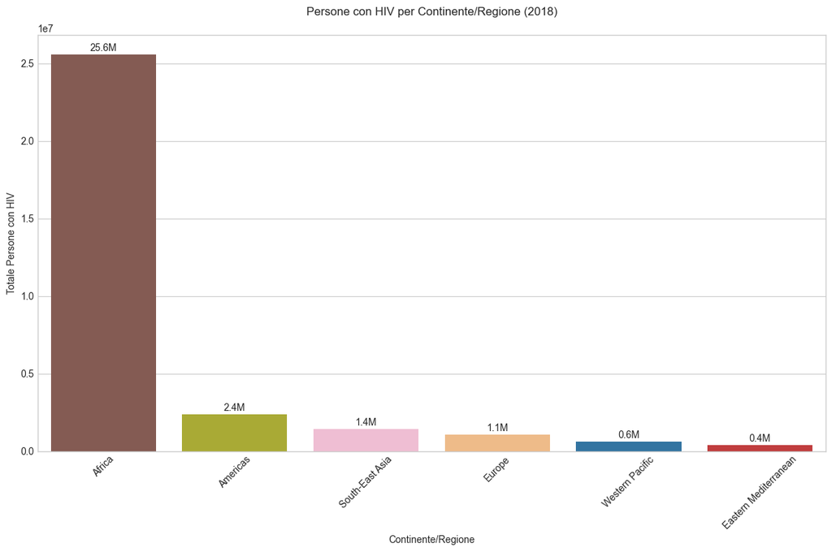

## 5) Top 15 e confronti

Confronto del numero totale di decessi per paese

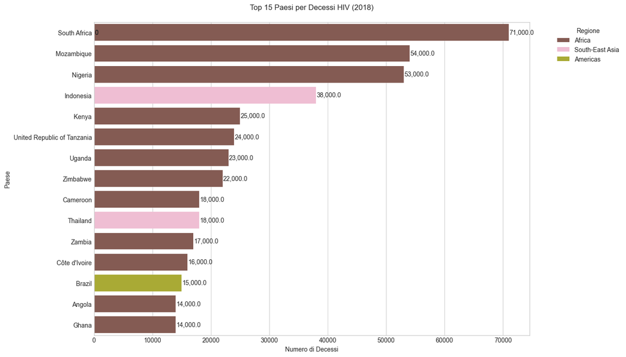

### 5.2 Confronto dei continenti

Confronto dei continenti/regioni geografiche, decessi

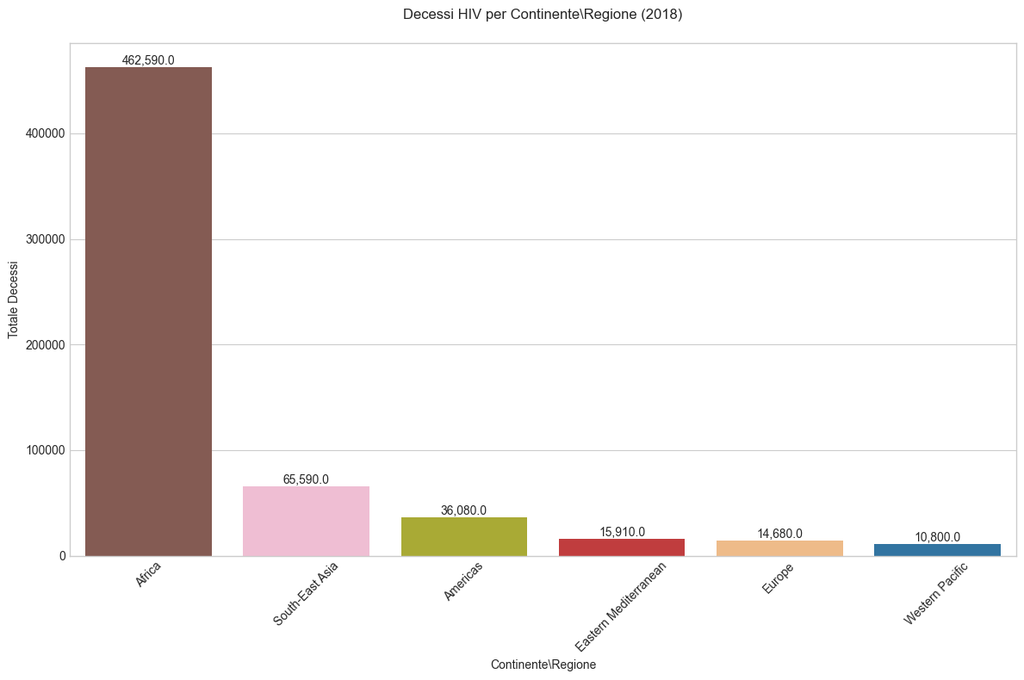

## 6) Più persone con HIV significano più decessi?

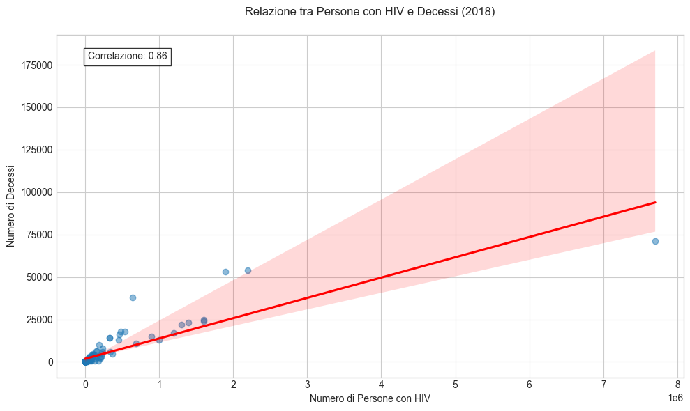

## 7) Trand storico

Il grafico mostra in dettaglio i trend storici per un gruppo di paesi selezionati (Afghanistan, Algeria, Angola, Argentina, Armenia).

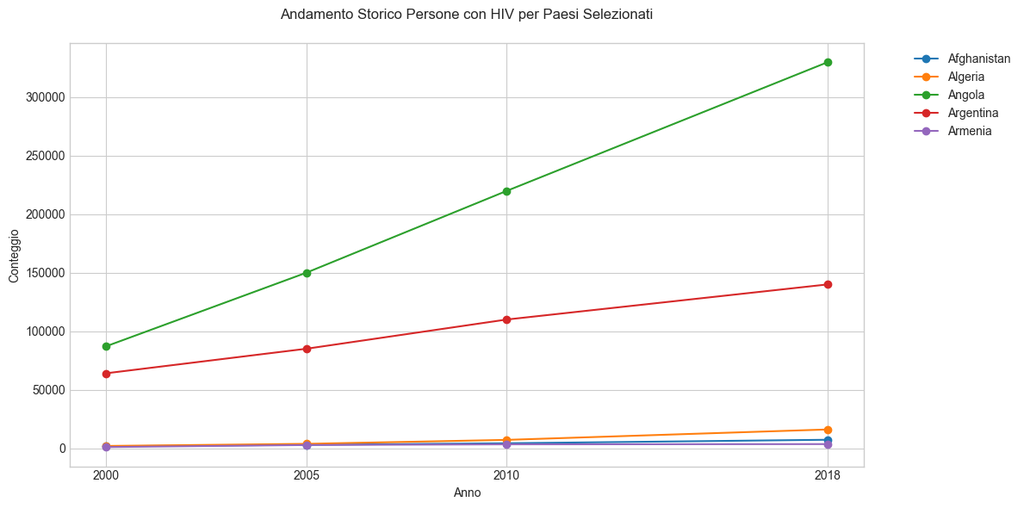

# Conclusioni

Questi risultati sottolineano l'importanza di mantenere alta l'attenzione sulla prevenzione e sulle cure.